# Comparing Extent of Student Engagement across different Academic Programs

Paolo G. Hilado

2022-04-27

Scenario: A comparison on the extent of student engagement is to be conducted to check whether interventions would be needed to entice students to participate in school activities. The team randomly sampled students (proportional allocation) from the four Academic Programs offered by the school and met the desired sample size computed via Modified Cochran.

## Open the data set

```r
library(xlsx)
data <- read.xlsx("StudentEngagement.xlsx", sheetIndex = "Sheet1")
```

## Check the first and last six rows, check the data structure and generate a summary

```r
head(data)
```

```
##   NA. Engagement    Acad
## 1   1       3.53 Nursing
## 2   2       4.53 Nursing
## 3   3       3.85 Nursing
## 4   4       3.91 Nursing
## 5   5       4.35 Nursing
## 6   6       3.46 Nursing
```

```r
tail(data)
```

```
##    NA. Engagement              Acad
## 73  73       3.77 Civil Engineering
## 74  74       3.36 Civil Engineering
## 75  75       2.87 Civil Engineering
## 76  76       3.81 Civil Engineering
## 77  77       3.56 Civil Engineering
## 78  78       3.38 Civil Engineering
```

```r
str(data)
```

```
## 'data.frame':    78 obs. of  3 variables:
##  $ NA.       : chr  "1" "2" "3" "4" ...
##  $ Engagement: num  3.53 4.53 3.85 3.91 4.35 3.46 4.3 5.05 4.6 3.51 ...
##  $ Acad      : chr  "Nursing" "Nursing" "Nursing" "Nursing" ...
```

```r
summary(data)
```

```
##      NA.              Engagement        Acad
##  Length:78          Min.   :2.160   Length:78
##  Class :character   1st Qu.:3.270   Class :character
##  Mode  :character   Median :3.635   Mode  :character
##                     Mean   :3.647
##                     3rd Qu.:4.018
##                     Max.   :5.210
```

## Clean data by removing the irrelevant feature

```r
data <- data[,-1]
```

## Subset data by Academic Program for Normality Testing

```r
unique(data$Acad)
```

```
## [1] "Nursing"                 "Business Administration"
## [3] "Computer Science"        "Civil Engineering"
```

```r
Nsg <- data[data$Acad == "Nursing",]$Engagement
BA <- data[data$Acad == "Business Administration",]$Engagement
CS <- data[data$Acad == "Computer Science",]$Engagement
CE <- data[data$Acad == "Civil Engineering",]$Engagement
```

## Conduct normality testing for each academic program

```r
library(nortest)
ad.test(Nsg)
```

```
##
##  Anderson-Darling normality test
##
## data:  Nsg
## A = 0.29386, p-value = 0.5579
```

```r
ad.test(BA)
```

```
##
##  Anderson-Darling normality test
##
## data:  BA
## A = 0.33658, p-value = 0.4768
```

```r
ad.test(CS)
```

```
##
##  Anderson-Darling normality test
##
## data:  CS
## A = 0.15365, p-value = 0.9488
```

```r
ad.test(CE)
```

```
##
##  Anderson-Darling normality test
##
## data:  CE
## A = 0.47463, p-value = 0.2096
```

```r
#Data sets tend to assume Normal Distribution
```

## Generate Probability Density Function Plots

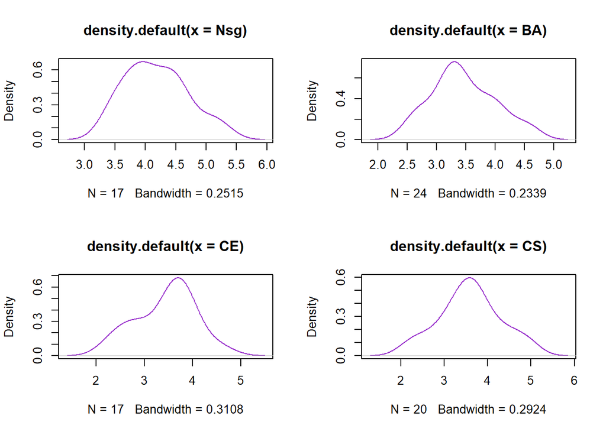

```r
par(mfrow=c(2,2))
plot(density(Nsg), col = "darkorchid")
plot(density(BA), col = "darkorchid")
plot(density(CE), col = "darkorchid")
plot(density(CS), col = "darkorchid")
```

## Generate BoxPlots

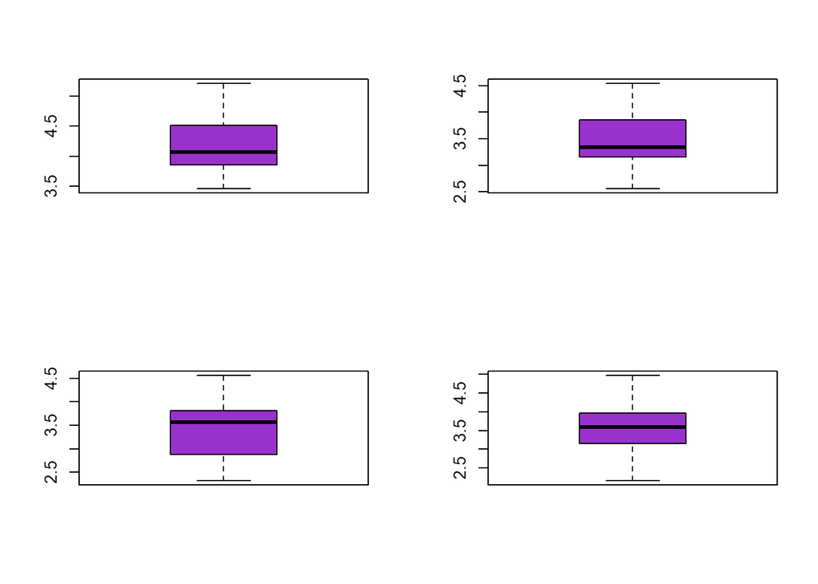

```r
par(mfrow=c(2,2))
boxplot(Nsg, col = "darkorchid")
boxplot(BA, col = "darkorchid")
boxplot(CE, col = "darkorchid")
boxplot(CS, col = "darkorchid")
```